# Data exploration

Author

Marina Kochuten

Published

February 4, 2025

## About

In this workflow, I am exploring the [plant pollinator interaction data at HJ Andrews Experimental Forest from 2011 to 2021](https://portal.edirepository.org/nis/metadataviewer?packageid=knb-lter-and.5216.8). At this point, I am working to familiarize myself with the data, do any necessary cleaning and wrangling, and explore potential trends through a handful of preliminary visualizations.

## Setup

```r
# Load libraries
library(tidyverse)
library(janitor)
library(here)

# Read in pollinator data
pp_interactions <- read_csv(here("data", "pp-interactions.csv")) |>
    clean_names()

# Not sure yet if I will use this data set, but this is where flower abundance data is kept
flower_surveys <- read_csv(here("data", "flower-surveys.csv")) |>
    clean_names()
```

## Exploration

### Structure of data

```r
# How many observations indicate pollination interactions?
print(paste("Number of pollinator interactions incidents in df:", count(pp_interactions, ppi_status)))
```

```
[1] "Number of pollinator interactions incidents in df: c(0, 1)"
[2] "Number of pollinator interactions incidents in df: c(13917, 61025)"
```

```r
print(count(pp_interactions, year))
```

```
# A tibble: 9 × 2
   year     n
  <dbl> <int>
1  2011 10275
2  2012  8185
3  2013  6565
4  2014 10850
5  2015  8496
6  2016  8034
7  2017  9507
8  2018 12219
9  2021   811
```

```r
# Missing data in 2019 and 2020, limited counts in 2021.
# I think I should filter to 2011-2018
```

### Pollination over time

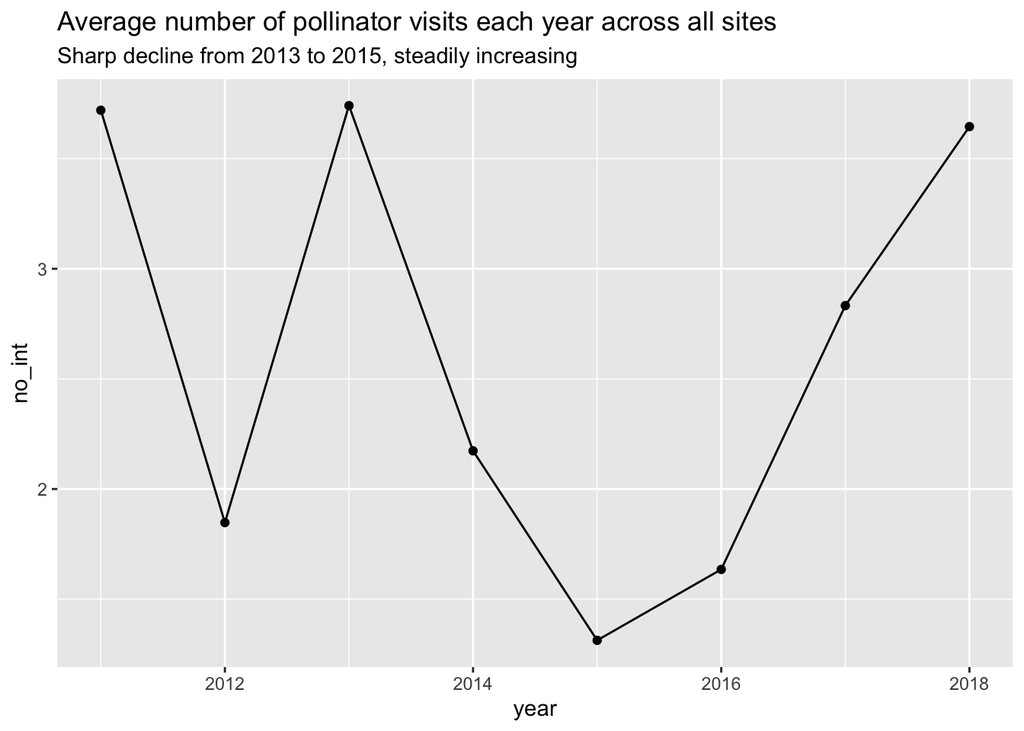

```r
# Let's take a look at the average number of pollinator visits each year
pp_interactions|>
    filter(year %in% c(2011:2018)) |>
    group_by(year) |>
    summarise(no_int = mean(no_int, na.rm = TRUE)) |>
    ungroup() |>
ggplot(aes(x = year, y = no_int)) +
    geom_point() +
    geom_line() +
    labs(title = "Average number of pollinator visits each year across all sites",
         subtitle = "Sharp decline from 2013 to 2015, steadily increasing")
```

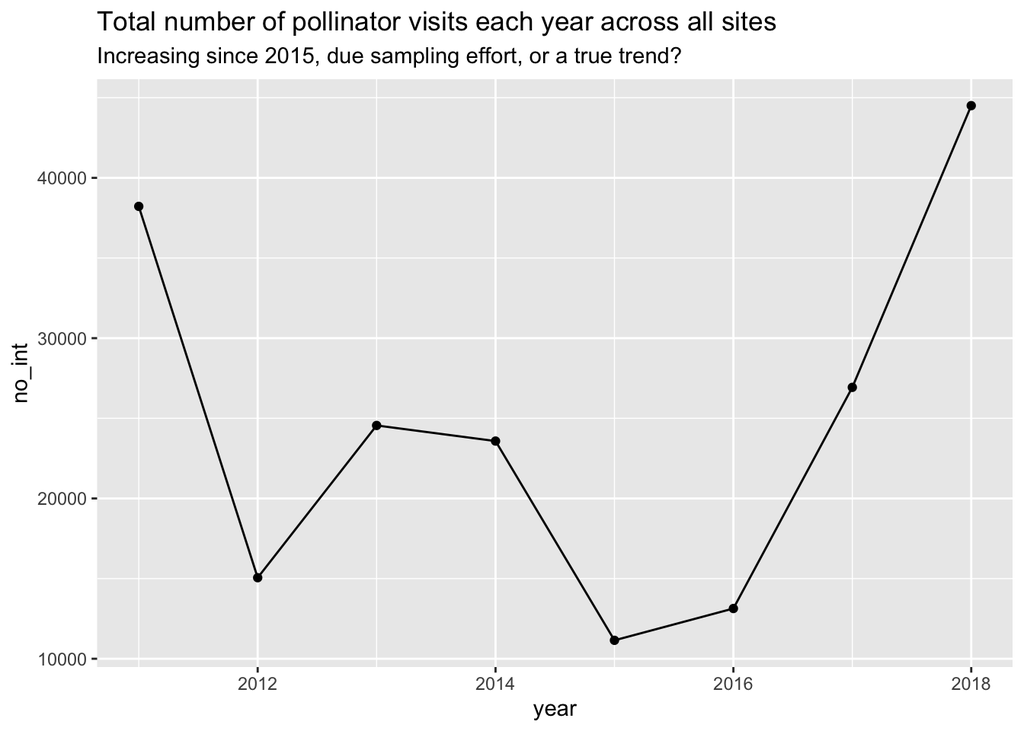

```r
# Let's also look at the total number of pollinator visits
pp_interactions|>
    filter(year %in% c(2011:2018)) |>
    group_by(year) |>
    summarise(no_int = sum(no_int, na.rm = TRUE)) |>
    ungroup() |>
ggplot(aes(x = year, y = no_int)) +
    geom_point() +
    geom_line() +
    labs(title = "Total number of pollinator visits each year across all sites",
         subtitle = "Increasing since 2015, due sampling effort, or a true trend?")
```

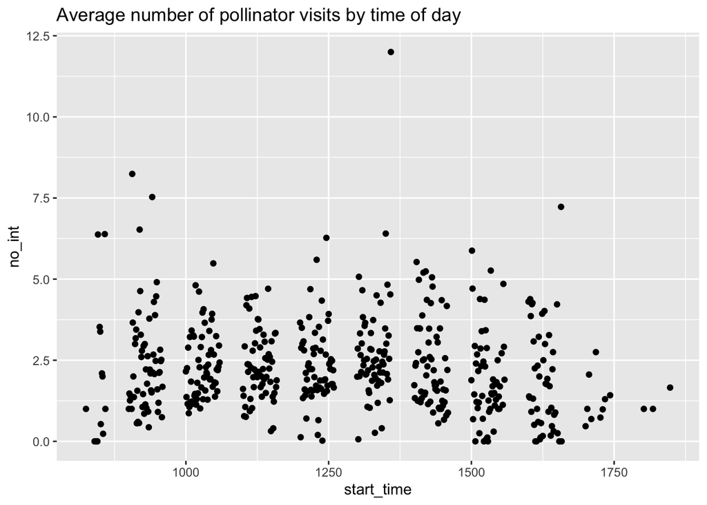

```r
# Look at hourly pollination trends
pp_interactions |>
    filter(year %in% c(2011:2018)) |>
    group_by(start_time) |>
    summarise(no_int = mean(no_int, na.rm = TRUE)) |>
    ungroup() |>
    ggplot(aes(x = start_time, y = no_int)) +
    geom_point() +
    labs(title = "Average number of pollinator visits by time of day")
```

### Pollination and weather

I’m curious to see how number of pollinator interactions vary under different weather conditions. My data contains the columns wind, clouds, and temp. Let’s take a look at those:

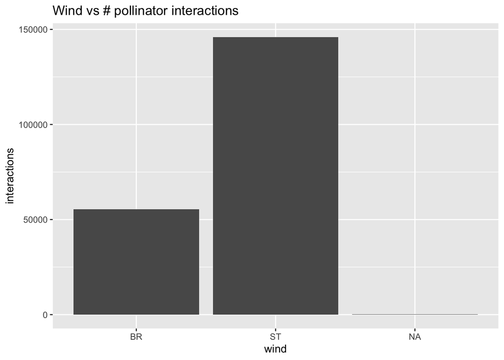

There are many more pollinator interactions observed when it is still (ST) rather than breezy (BR)

```r
# Wind vs # of pollinator interactions
pp_interactions |>
    group_by(wind) |>
    summarise(interactions = sum(no_int, na.rm=TRUE)) |>
    ungroup() |>
    ggplot(aes(x = wind, y = interactions)) +
    geom_col() +
    labs(title = "Wind vs # pollinator interactions")
```

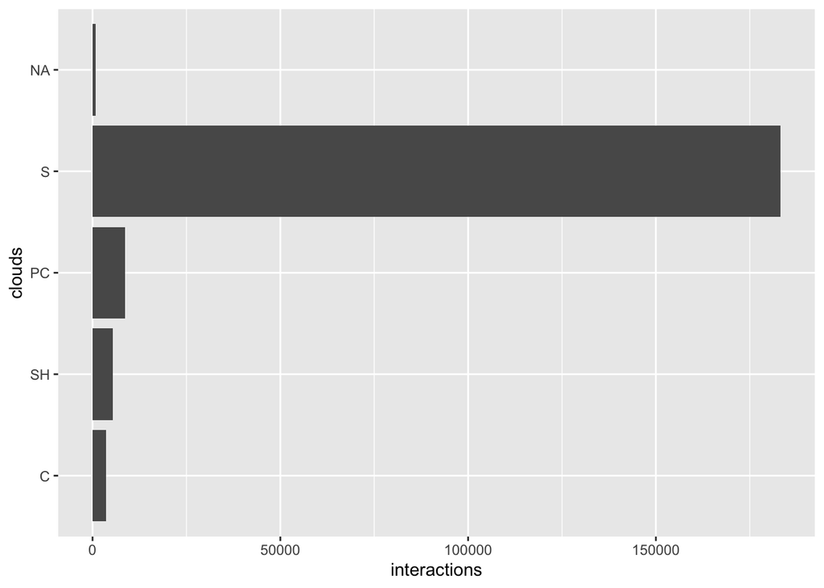

As expected, there are many more pollinator interactions observed when it is sunny, and interactions decrease as clouds increase

```r
# Clouds vs # of pollinator interactions
pp_interactions |>
    group_by(clouds) |>
    summarise(interactions = sum(no_int, na.rm=TRUE)) |>
    ungroup() |>
    mutate(clouds = fct_reorder(clouds, interactions)) |>
    ggplot(aes(x = clouds, y = interactions)) +
    geom_col() +
    coord_flip()
```

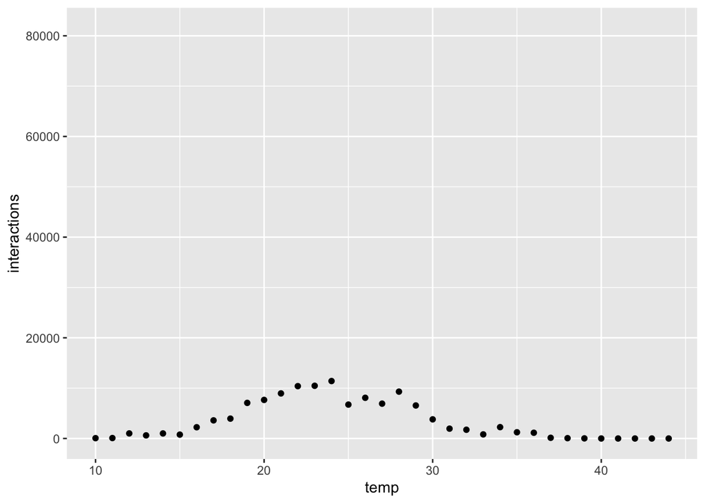

Seems like there is a sweet spot for pollinators around 25 degrees. I wonder if this is because of average temp when the most flowers are blooming?

```r
# Temp vs # of pollinator interactions
pp_interactions |>
    group_by(temp) |>
    summarise(interactions = sum(no_int, na.rm=TRUE)) |>
    ungroup() |>
    ggplot(aes(x = temp, y = interactions)) +
    geom_point()
```

### Pollinator type

Now, I’d like to explore potential trends regarding pollinator type. First, I want to group the specific pollinator species into generic types:

```r
# Add a column with pollinator generic type
pp_interactions <- pp_interactions |>
    mutate(pol_type = case_when(str_detect(vissp_type, "beetle") ~ "Beetle",
                                str_detect(vissp_type, "fly") ~ "Fly",
                                str_detect(vissp_type, "wasp") ~ "Wasp",
                                str_detect(vissp_type, "butterfly") ~ "Butterfly",
                                str_detect(vissp_type, "grasshopper") ~ "Grasshopper",
                                str_detect(vissp_type, "moth") ~ "Moth",
                                str_detect(vissp_type, "hummingbird") ~ "Hummingbird",
                                str_detect(vissp_type, "bee") ~ "Bee",
                                str_detect(vissp_type, "ant") ~ "Ant",
                                str_detect(vissp_type, "spider") ~ "Spider",
                                .default = "other"))
```

Now I can poke around with potential pollinator type trends

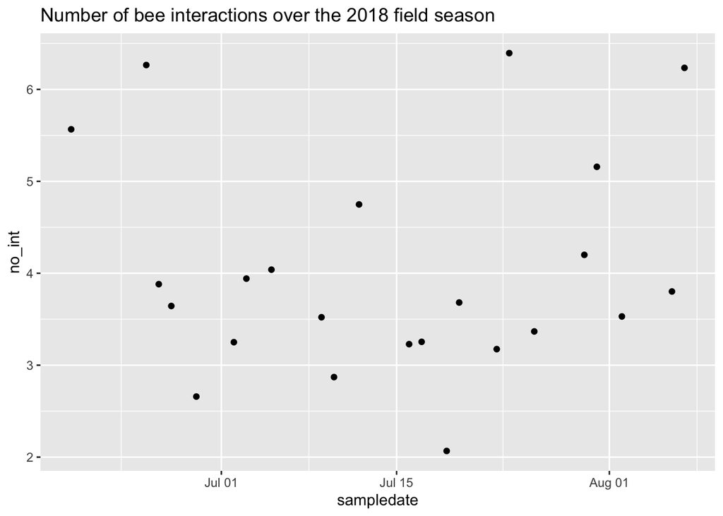

There is not any clearly visible trend regarding number of bee interactions over the 2018 season

```r
# Number of bee interactions over the 2018 field season
pp_interactions |>
    filter(year == 2018) |>
    filter(pol_type == "Bee") |>
    group_by(pol_type, sampledate) |>
    summarise(no_int = mean(no_int, na.rm = TRUE)) |>
    ggplot(aes(x = sampledate, y = no_int)) +
    labs(title = "Number of bee interactions over the 2018 field season") +
    geom_point()
```

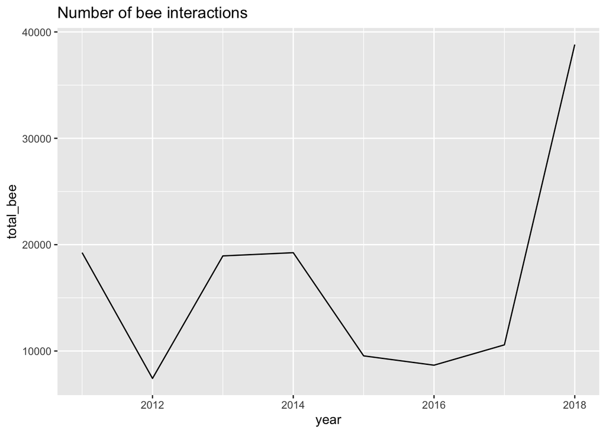

Number of bees observed is cyclical, with a huge year in 2018. Important to note that in 2021 only visitations by bees were recorded rather than visitations by all pollinators, so this year was removed.

```r
# Average number of bee interactions over time?
pp_interactions |>
    filter(year != 2021) |>
    filter(pol_type == "Bee") |>
    group_by(year) |>
    summarise(total_bee = sum(no_int, na.rm = TRUE)) |>
    ggplot(aes(x = year, y = total_bee)) +
    geom_line() +
    labs(title = "Number of bee interactions")
```

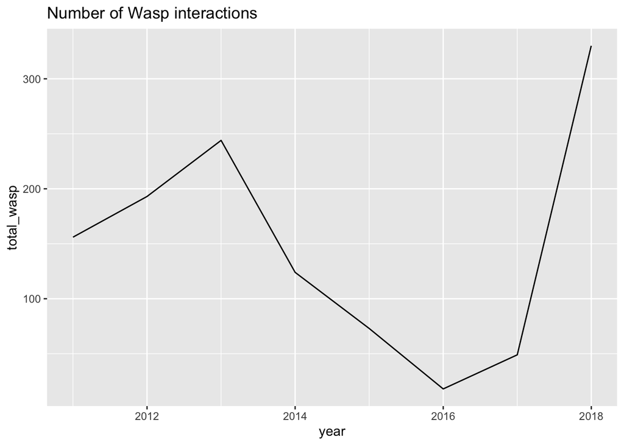

```r
# Average number of wasp interactions over time?
pp_interactions |>
    filter(year != 2021) |>
    filter(pol_type == "Wasp") |>
    group_by(year) |>
    summarise(total_wasp = sum(no_int, na.rm = TRUE)) |>
    ggplot(aes(x = year, y = total_wasp)) +
    geom_line() +
    labs(title = "Number of Wasp interactions")
```

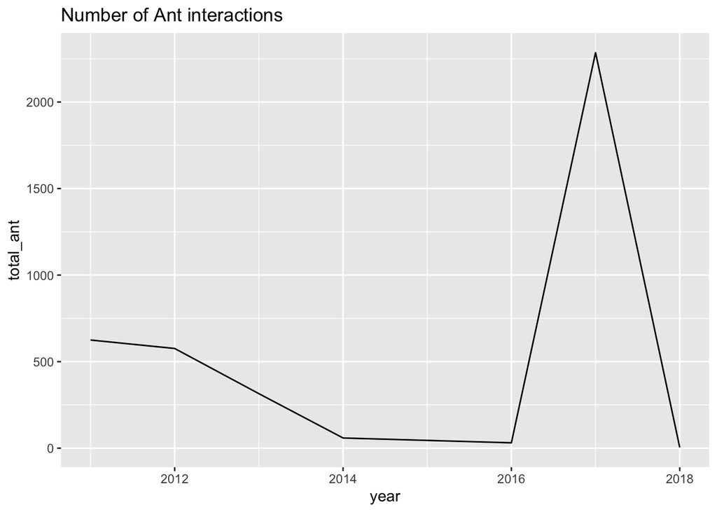

```r
# Average number of ant interactions over time?
pp_interactions |>
    filter(year != 2021) |>
    filter(pol_type == "Ant") |>
    group_by(year) |>
    summarise(total_ant = sum(no_int, na.rm = TRUE)) |>
    ggplot(aes(x = year, y = total_ant)) +
    geom_line() +
    labs(title = "Number of Ant interactions")
```

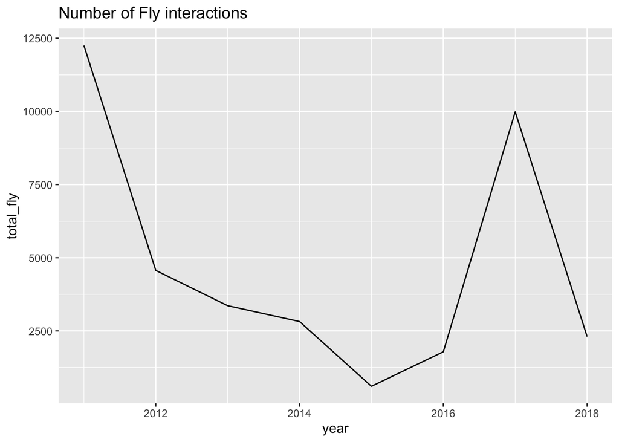

```r
# Average number of fly interactions over time?
pp_interactions |>
    filter(year != 2021) |>
    filter(pol_type == "Fly") |>
    group_by(year) |>
    summarise(total_fly = sum(no_int, na.rm = TRUE)) |>
    ggplot(aes(x = year, y = total_fly)) +
    geom_line() +
    labs(title = "Number of Fly interactions")
```

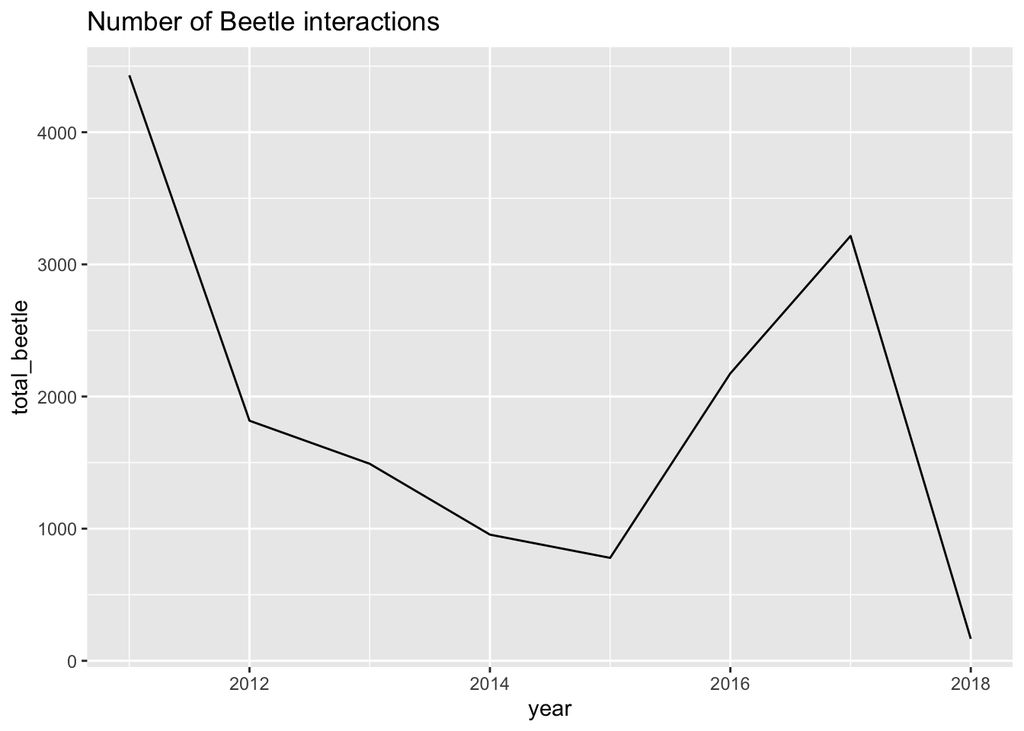

```r
# Average number of beetle interactions over time?
pp_interactions |>
    filter(year != 2021) |>
    filter(pol_type == "Beetle") |>
    group_by(year) |>
    summarise(total_beetle = sum(no_int, na.rm = TRUE)) |>
    ggplot(aes(x = year, y = total_beetle)) +
    geom_line() +
    labs(title = "Number of Beetle interactions")
```

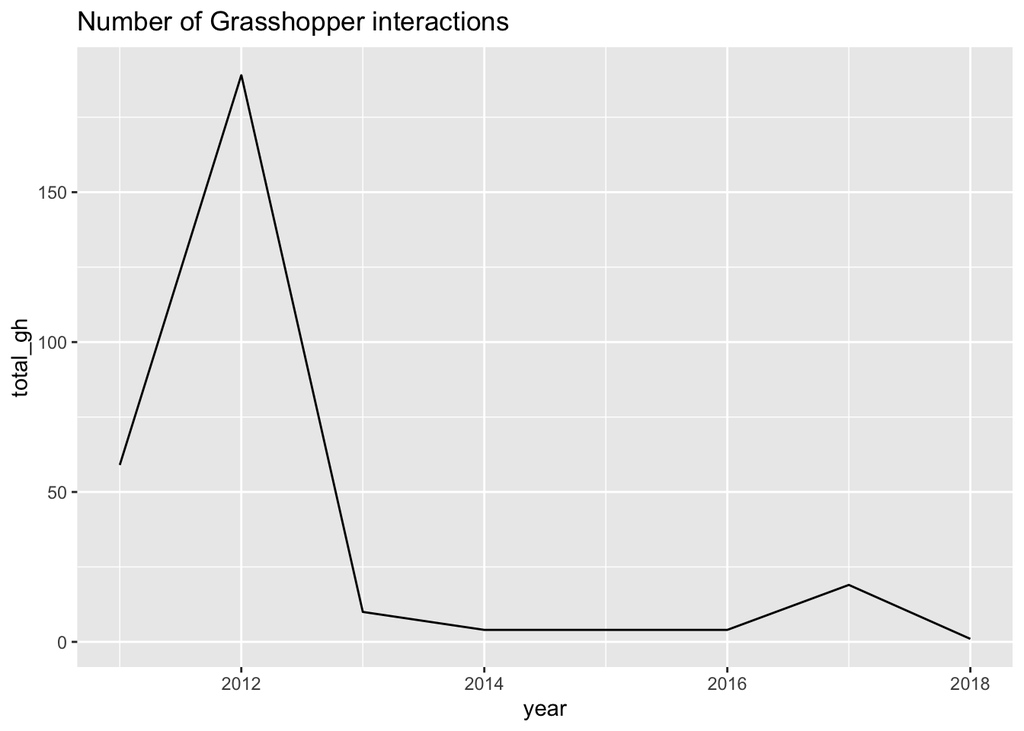

```r
# Average number of grasshopper interactions over time?
pp_interactions |>
    filter(year != 2021) |>
    filter(pol_type == "Grasshopper") |>
    group_by(year) |>
    summarise(total_gh = sum(no_int, na.rm = TRUE)) |>
    ggplot(aes(x = year, y = total_gh)) +
    geom_line() +
    labs(title = "Number of Grasshopper interactions")
```

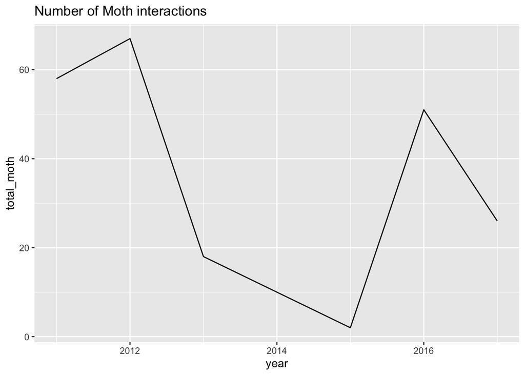

```r
# Average number of moth interactions over time?
pp_interactions |>
    filter(year != 2021) |>
    filter(pol_type == "Moth") |>
    group_by(year) |>
    summarise(total_moth = sum(no_int, na.rm = TRUE)) |>
    ggplot(aes(x = year, y = total_moth)) +
    geom_line() +
    labs(title = "Number of Moth interactions")
```

Haha, that was fun.

### Pollinator types and specific flower species

It could be interesting to do some research to identify important or noteworthy meadow flower species and see which polliators they are most visited by.

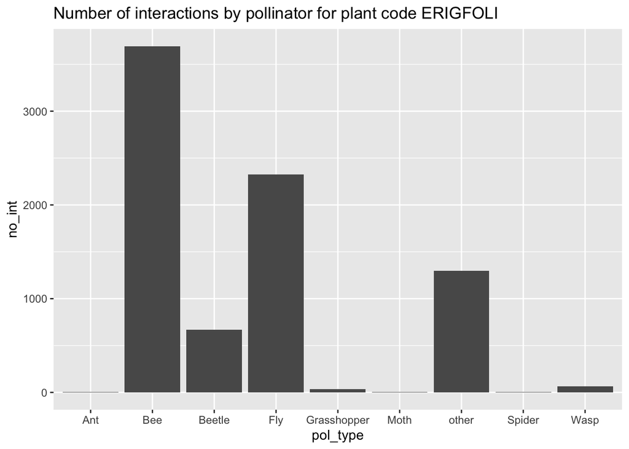

```r
# could see pollinator types by plant species - potentially identify important species?
pp_interactions |>
    group_by(pltsp_code, pol_type) |>
    summarise(no_int = sum(no_int, na.rm = TRUE)) |>
    filter(pltsp_code == "ERIGFOLI") |>
    ggplot(aes(x = pol_type, y = no_int)) +
    geom_col() +
    labs(title = "Number of interactions by pollinator for plant code ERIGFOLI")
```

### Important plants for specific pollinators

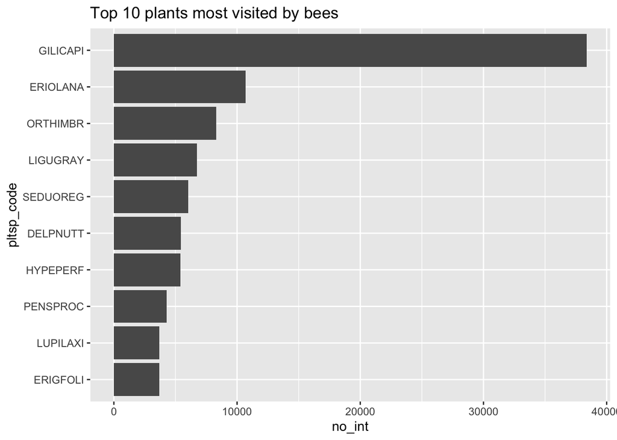

```r
# Explore most important plant species for bees?
pp_interactions |>
    group_by(pltsp_code, pol_type) |>
    summarise(no_int = sum(no_int, na.rm = TRUE)) |>
    ungroup() |>
    filter(pol_type == "Bee") |>
    mutate(pltsp_code = fct_reorder(pltsp_code, no_int)) |>
    arrange(desc(no_int)) |>
    slice_head(n = 10) |>
    ggplot(aes(x = pltsp_code, y = no_int)) +
    geom_col() +
    labs(title = "Top 10 plants most visited by bees") +
    coord_flip()
```

```r
# The biggest one is Gilia capitata: "Globe gilia is very attractive to honey bees"
```